# Predictors of Mortality in CLD with renal dysfunction

Anupam kumar Singh, MD

2 November 2017

we will try to evaluate factors affecting mortality in HRS . We have already calculated descritive statistics, done ANOVA of NGAL and done comparative ROC Aanalysis of biomarkers like FeNa,NGAL,Urine Na,Urine Creatinine which are accessible along with master chart [here](https://drive.google.com/open?id=0B7gX8b7uHJW2LUhhYnF1NVNoUWc)

Let us do survival analysis now, first dplyr::select limited variables

Lets prepare our data for survival analysis

```
## Call: survfit(formula = Surv(days, status) ~ 1, data = master2)
##
##  time n.risk n.event survival std.err lower 95% CI upper 95% CI
##    30     94      18    0.809  0.0406        0.733        0.892
##    90     76       5    0.755  0.0443        0.673        0.847
```

survival plot from same

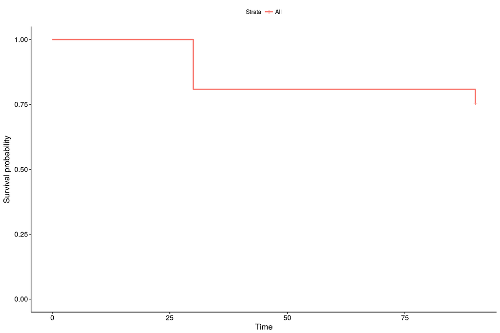

classifying CTP n MELD for further use in survival curves

Plot survival by diagnosetic categories

```
## Call: survfit(formula = Surv(days, status) ~ diagnoses, data = master3)
##
##                 diagnoses=CKD
##  time n.risk n.event survival std.err lower 95% CI upper 95% CI
##    30      9       1    0.889   0.105        0.706            1
##    90      8       1    0.778   0.139        0.549            1
##
##                 diagnoses=HRS
##  time n.risk n.event survival std.err lower 95% CI upper 95% CI
##    30     33      10    0.697  0.0800        0.557        0.873
##    90     23       3    0.606  0.0851        0.460        0.798
##
##                 diagnoses=iAKI
##  time n.risk n.event survival std.err lower 95% CI upper 95% CI
##    30     10       5      0.5   0.158        0.269        0.929
##    90      5       1      0.4   0.155        0.187        0.855
##
##                 diagnoses=Prerenal
##         time       n.risk      n.event     survival      std.err
##      30.0000      32.0000       2.0000       0.9375       0.0428
## lower 95% CI upper 95% CI
##       0.8573       1.0000
```

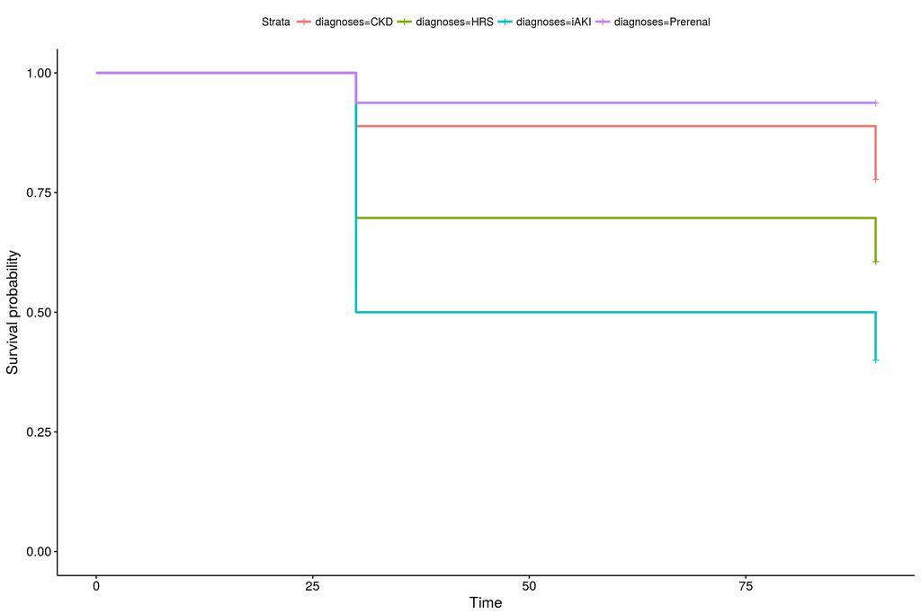

Plot survival by MELD category

```
## Call: survfit(formula = Surv(days, status) ~ MELD_CAT, data = master3)
##
##                 MELD_CAT=MELD<=10
##         time       n.risk      n.event     survival      std.err
##       90.000        3.000        1.000        0.667        0.272
## lower 95% CI upper 95% CI
##        0.300        1.000
##
##                 MELD_CAT=MELD(10-18)
##  time n.risk n.event survival std.err lower 95% CI upper 95% CI
##    30     27       3    0.889  0.0605        0.778        1.000
##    90     24       1    0.852  0.0684        0.728        0.997
##
##                 MELD_CAT=MELD(19-24)
##         time       n.risk      n.event     survival      std.err
##      30.0000      28.0000       5.0000       0.8214       0.0724
## lower 95% CI upper 95% CI
##       0.6911       0.9763
##
##                 MELD_CAT=MELD>=25
##  time n.risk n.event survival std.err lower 95% CI upper 95% CI
##    30     26      10    0.615  0.0954        0.454        0.834
##    90     16       3    0.500  0.0981        0.340        0.734
```

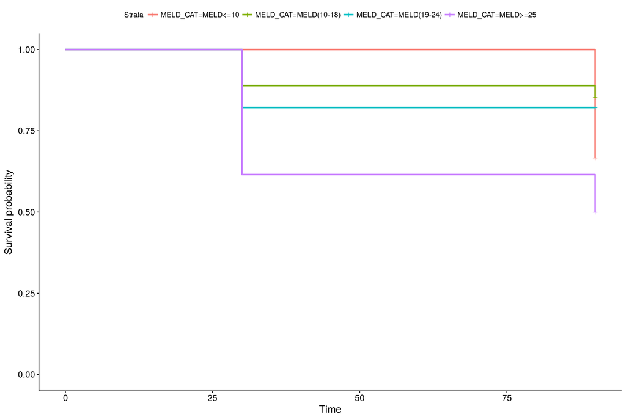

Plot survival by CTP

```
## Call: survfit(formula = Surv(days, status) ~ CTP_CATEGORIES, data = master3)
##
##                 CTP_CATEGORIES=B
##  time n.risk n.event survival std.err lower 95% CI upper 95% CI
##    30     47       8    0.830  0.0548        0.729        0.944
##    90     39       3    0.766  0.0618        0.654        0.897
##
##                 CTP_CATEGORIES=C
##  time n.risk n.event survival std.err lower 95% CI upper 95% CI
##    30     37      10    0.730   0.073         0.60        0.888
##    90     27       2    0.676   0.077         0.54        0.845
```

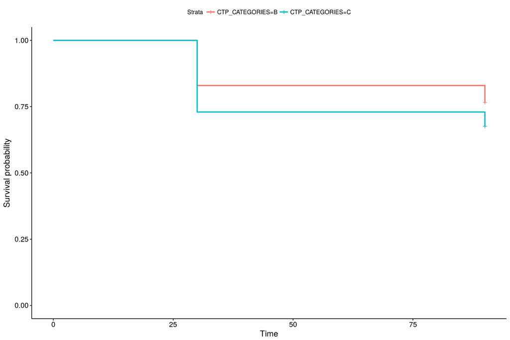

Let us do multivariate analysis of mortality with predictive factor

```
##
## Call:
## glm(formula = as.factor(outcome_30) ~ age + MELD, family = binomial(),
##     data = master)
##
## Deviance Residuals:
##     Min       1Q   Median       3Q      Max
## -1.2479  -0.6459  -0.4810  -0.3371   2.3154
##
## Coefficients:
##             Estimate Std. Error z value Pr(>|z|)
## (Intercept) -3.35611    1.54531  -2.172  0.02987 *
## age         -0.01254    0.02341  -0.536  0.59227
## MELD         0.11346    0.03990   2.843  0.00446 **
## ---
## Signif. codes:  0 '***' 0.001 '**' 0.01 '*' 0.05 '.' 0.1 ' ' 1
##
## (Dispersion parameter for binomial family taken to be 1)
##
##     Null deviance: 91.815  on 93  degrees of freedom
## Residual deviance: 81.183  on 91  degrees of freedom
## AIC: 87.183
##
## Number of Fisher Scoring iterations: 4
```

Lets add NGAL to model with MELD only and see improvement in AIC has been used often

```
##
## Call:
## glm(formula = as.factor(outcome_30) ~ age + NGAL + MELD, family = binomial(),
##     data = master)
##
## Deviance Residuals:
##     Min       1Q   Median       3Q      Max
## -1.7072  -0.6101  -0.3770  -0.2836   2.5033
##
## Coefficients:
##               Estimate Std. Error z value Pr(>|z|)
## (Intercept) -4.4395768  1.6723988  -2.655  0.00794 **
## age          0.0007788  0.0241383   0.032  0.97426
## NGAL         0.0021566  0.0007445   2.897  0.00377 **
## MELD         0.0879044  0.0424967   2.068  0.03859 *
## ---
## Signif. codes:  0 '***' 0.001 '**' 0.01 '*' 0.05 '.' 0.1 ' ' 1
##
## (Dispersion parameter for binomial family taken to be 1)
##
##     Null deviance: 91.815  on 93  degrees of freedom
## Residual deviance: 72.054  on 90  degrees of freedom
## AIC: 80.054
##
## Number of Fisher Scoring iterations: 5
```

so adding NGAL to model leads to decrease in AIC (>1) more than implying its an effective variable

```
##
## Call:
## glm(formula = as.factor(outcome_30) ~ age + NGAL + MELD + serum_sodium,
##     family = binomial(), data = master)
##
## Deviance Residuals:
##     Min       1Q   Median       3Q      Max
## -1.7422  -0.5964  -0.3833  -0.2638   2.4996
##
## Coefficients:
##                Estimate Std. Error z value Pr(>|z|)
## (Intercept)  -6.7983469  5.5066227  -1.235   0.2170
## age           0.0014307  0.0241404   0.059   0.9527
## NGAL          0.0021394  0.0007454   2.870   0.0041 **
## MELD          0.0934692  0.0445050   2.100   0.0357 *
## serum_sodium  0.0167365  0.0369826   0.453   0.6509
## ---
## Signif. codes:  0 '***' 0.001 '**' 0.01 '*' 0.05 '.' 0.1 ' ' 1
##
## (Dispersion parameter for binomial family taken to be 1)
##
##     Null deviance: 91.815  on 93  degrees of freedom
## Residual deviance: 71.848  on 89  degrees of freedom
## AIC: 81.848
##
## Number of Fisher Scoring iterations: 5
```

Adding serum sodium doesnt lead to fall in AIC, so even adding an extra predictor isnt improving predictive power of our model

```
## Analysis of Deviance Table
##
## Model 1: as.factor(outcome_30) ~ age + MELD
## Model 2: as.factor(outcome_30) ~ age + NGAL + MELD
##   Resid. Df Resid. Dev Df Deviance
## 1        91     81.183
## 2        90     72.054  1   9.1292
```

Let’s do ROC curve analysis of our model with MELD,NGAL

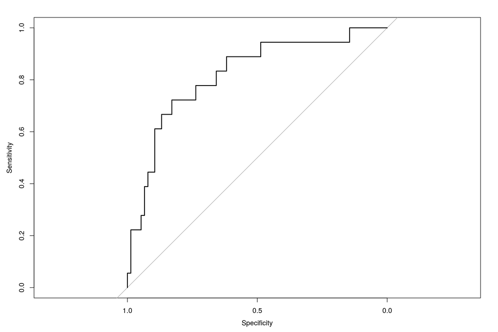

```
## Area under the curve: 0.818
```

thus AUC of combined MELD n NGAL model is 0.818

```
## Logistic Regression Model
##
##  lrm(formula = outcome_30 ~ age + NGAL + MELD, data = master4,
##      x = TRUE, y = TRUE)
##
##                        Model Likelihood     Discrimination    Rank Discrim.
##                           Ratio Test           Indexes           Indexes
##  Obs             94    LR chi2     19.76    R2       0.304    C       0.817
##   a              76    d.f.            3    g        1.351    Dxy     0.635
##   d              18    Pr(> chi2) 0.0002    gr       3.861    gamma   0.636
##  max |deriv| 0.0002                         gp       0.189    tau-a   0.199
##                                             Brier    0.121
##
##            Coef    S.E.   Wald Z Pr(>|Z|)
##  Intercept -4.4396 1.6724 -2.65  0.0079
##  age        0.0008 0.0241  0.03  0.9743
##  NGAL       0.0022 0.0007  2.90  0.0038
##  MELD       0.0879 0.0425  2.07  0.0386
##
```

Nomogram of model

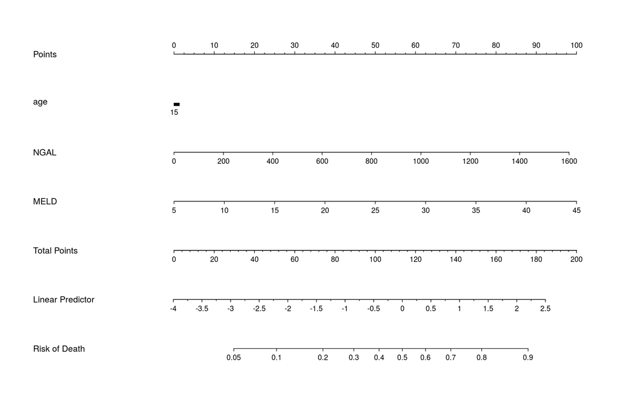

Let’s do internal validation bootstrap

```
##           index.orig training    test optimism index.corrected   n
## Dxy           0.6360   0.6533  0.5919   0.0614          0.5746 200
## R2            0.3041   0.3465  0.2700   0.0765          0.2276 200
## Intercept     0.0000   0.0000 -0.0732   0.0732         -0.0732 200
## Slope         1.0000   1.0000  0.8843   0.1157          0.8843 200
## Emax          0.0000   0.0000  0.0400   0.0400          0.0400 200
## D             0.1996   0.2349  0.1740   0.0609          0.1387 200
## U            -0.0213  -0.0213  0.0210  -0.0422          0.0210 200
## Q             0.2209   0.2562  0.1531   0.1032          0.1177 200
## B             0.1213   0.1097  0.1285  -0.0188          0.1401 200
## g             1.3509   1.5624  1.2310   0.3314          1.0194 200
## gp            0.1889   0.1930  0.1767   0.0163          0.1726 200
```

so our bootstrapped model shows considerable optimism implying on external validation our model is going to fare worse

lets’s see calibration estimates

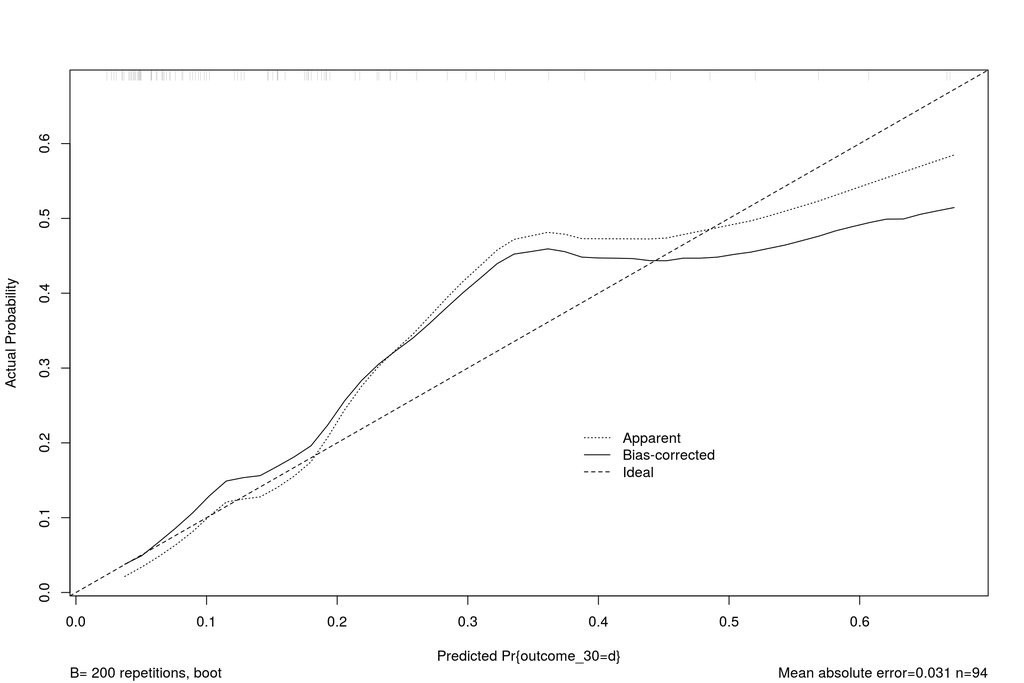

```
##
## n=94   Mean absolute error=0.031   Mean squared error=0.0024
## 0.9 Quantile of absolute error=0.091
```

we can see while negative predictive probability is good the positive predictive of our model fares a bit worse

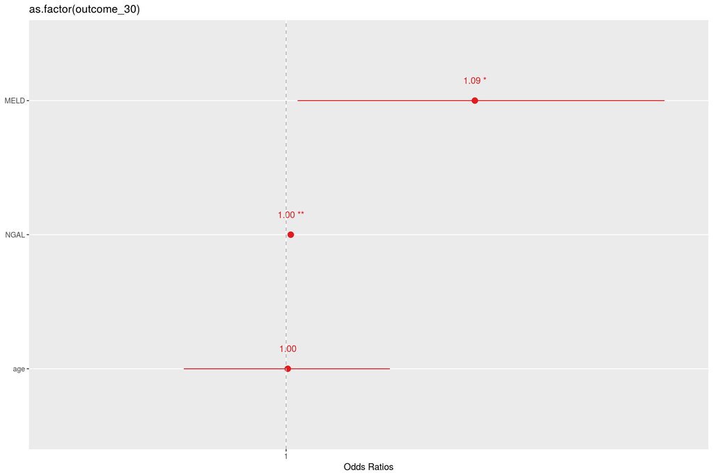

Lets calculate adjusted odds ratio from our final model

```
##                               2.5 %    97.5 %
## (Intercept) 0.01180093 0.0003549703 0.2734832
## age         1.00077911 0.9534518891 1.0495262
## NGAL        1.00215897 1.0007490347 1.0037256
## MELD        1.09188369 1.0053542303 1.1927184
```